# RetailForecast

2026-04-26

```r
library(dplyr)
library(tsibble)
library(feasts)
```

```r
library(ggplot2)
library(fpp3)
df <- read.csv('/Users/johnmatthewsarong/Personal Projects/CSV/retail_sales.csv')
unique(df$store_id)   # Checking the unique values in store columns
```

```
##  [1] "store_1"  "store_2"  "store_3"  "store_4"  "store_5"  "store_6"
##  [7] "store_7"  "store_8"  "store_9"  "store_10" "store_11" "store_12"
## [13] "store_13" "store_14" "store_15" "store_16" "store_17" "store_18"
## [19] "store_19" "store_20" "store_21" "store_22" "store_23" "store_24"
## [25] "store_25" "store_26" "store_27" "store_28" "store_29" "store_30"
## [31] "store_31" "store_32" "store_33" "store_34" "store_35" "store_36"
## [37] "store_37" "store_38" "store_39" "store_40" "store_41" "store_42"
## [43] "store_43" "store_44" "store_45" "store_46" "store_47" "store_48"
## [49] "store_49" "store_50"
```

```r
unique(df$item_id)    # Checking the unique values in item columns
```

```
##  [1] "item_1"  "item_2"  "item_3"  "item_4"  "item_5"  "item_6"  "item_7"
##  [8] "item_8"  "item_9"  "item_10" "item_11" "item_12" "item_13" "item_14"
## [15] "item_15" "item_16" "item_17" "item_18" "item_19" "item_20" "item_21"
## [22] "item_22" "item_23" "item_24" "item_25" "item_26" "item_27" "item_28"
## [29] "item_29" "item_30" "item_31" "item_32" "item_33" "item_34" "item_35"
## [36] "item_36" "item_37" "item_38" "item_39" "item_40" "item_41" "item_42"
## [43] "item_43" "item_44" "item_45" "item_46" "item_47" "item_48" "item_49"
## [50] "item_50"
```

```r
sum(is.na(df))        # Checking for missing values
```

```
## [1] 0
```

```r
summary(df)           # Visualizing the dataset summary
```

```
##      date             store_id           item_id              sales
##  Length:4565000     Length:4565000     Length:4565000     Min.   :  0.00
##  Class :character   Class :character   Class :character   1st Qu.: 18.00
##  Mode  :character   Mode  :character   Mode  :character   Median : 27.00
##                                                           Mean   : 29.26
##                                                           3rd Qu.: 38.00
##                                                           Max.   :139.00
##      price           promo        weekday          month
##  Min.   : 8.02   Min.   :0.0   Min.   :0.000   Min.   : 1.000
##  1st Qu.:31.97   1st Qu.:0.0   1st Qu.:1.000   1st Qu.: 4.000
##  Median :53.52   Median :0.0   Median :3.000   Median : 7.000
##  Mean   :53.99   Mean   :0.1   Mean   :3.002   Mean   : 6.524
##  3rd Qu.:75.36   3rd Qu.:0.0   3rd Qu.:5.000   3rd Qu.:10.000
##  Max.   :99.99   Max.   :1.0   Max.   :6.000   Max.   :12.000
```

```r
head(df, 10)          # Checking frst 10 values
```

```
##          date store_id item_id sales price promo weekday month
## 1  2019-01-01  store_1  item_1    41 21.30     0       1     1
## 2  2019-01-02  store_1  item_1    53 21.30     0       2     1
## 3  2019-01-03  store_1  item_1    39 21.30     0       3     1
## 4  2019-01-04  store_1  item_1    35 21.30     0       4     1
## 5  2019-01-05  store_1  item_1    51 17.04     1       5     1
## 6  2019-01-06  store_1  item_1    38 21.30     0       6     1
## 7  2019-01-07  store_1  item_1    45 21.30     0       0     1
## 8  2019-01-08  store_1  item_1    48 21.30     0       1     1
## 9  2019-01-09  store_1  item_1    50 21.30     0       2     1
## 10 2019-01-10  store_1  item_1    44 21.30     0       3     1
```

```r
tail(df, 10)
```

```
##               date store_id item_id sales price promo weekday month
## 4564991 2023-12-22 store_50 item_50    23 64.10     1       4    12
## 4564992 2023-12-23 store_50 item_50    11 80.12     0       5    12
## 4564993 2023-12-24 store_50 item_50    13 80.12     0       6    12
## 4564994 2023-12-25 store_50 item_50    16 80.12     0       0    12
## 4564995 2023-12-26 store_50 item_50    15 80.12     0       1    12
## 4564996 2023-12-27 store_50 item_50    28 64.10     1       2    12
## 4564997 2023-12-28 store_50 item_50    15 80.12     0       3    12
## 4564998 2023-12-29 store_50 item_50    12 80.12     0       4    12
## 4564999 2023-12-30 store_50 item_50    11 80.12     0       5    12
## 4565000 2023-12-31 store_50 item_50    10 80.12     0       6    12
```

```r
# Checking for outliers in sales column
Q1 <- quantile(df[['sales']], 0.25)
Q3 <- quantile(df[['sales']], 0.75)
IQR <- Q3 - Q1

lower <- Q1 - 1.5 * IQR
upper <- Q3 + 1.5 * IQR

mask = df[['sales']] < lower | df[['sales']] > upper
outliers = df[mask, ]
summary(outliers[['sales']])
```

```
##    Min. 1st Qu.  Median    Mean 3rd Qu.    Max.
##   69.00   71.00   76.00   78.69   83.00  139.00
```

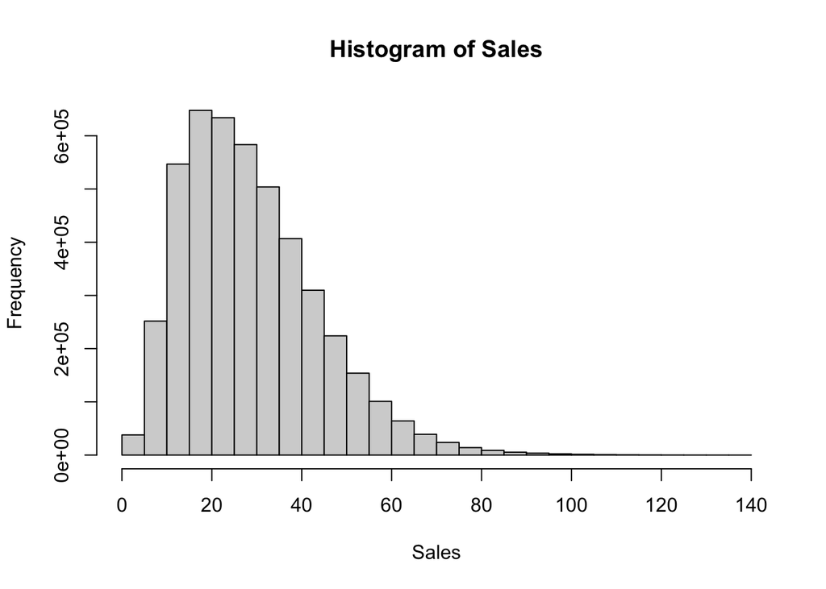

```r
hist(df[['sales']], breaks = 30,
     main = 'Histogram of Sales',
     xlab = 'Sales',
     ylab = 'Frequency')
```

```r
sum(mask)
```

```
## [1] 74236
```

```r
# Filter out duplicates: Keep the first instance
df <- df %>% distinct(date, .keep_all = TRUE)
```

**Outlier Handling** After appling the IQR rule, I ibserved that there are huge amount of outliers. After visualizing the histogram, I also found that the sales distribution is heavily right-skewed. Further, I am not removing outliers as they could represent actual sales from busy days.

```r
class(df$date)                                  # Date column is a character
```

```
## [1] "character"
```

```
## Plot variable not specified, automatically selected `.vars = sales`
```

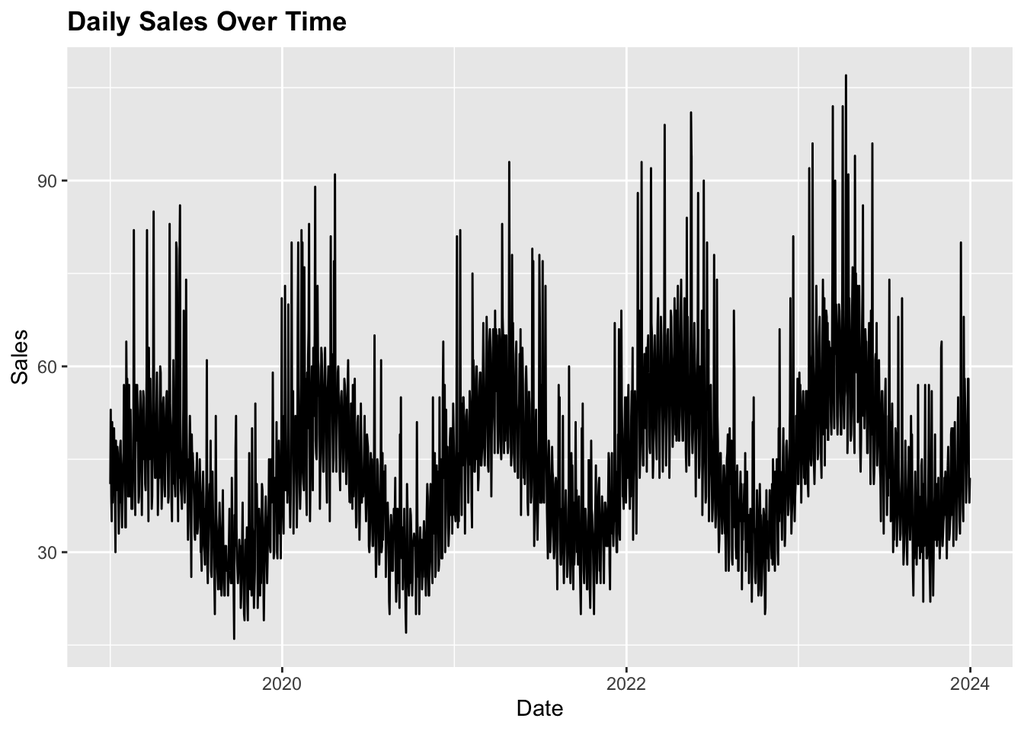

```r
df <- df %>% mutate(date = as.Date(date))       # Mutate the column into dates

# Convert the dataframe into a tsibble for forecasting
df_ts <- df %>% as_tsibble(index=date)
autoplot(df_ts) +
  labs(title = 'Daily Sales Over Time',
           x = 'Date',
           y = 'Sales') + theme (
             plot.title = element_text(face = 'bold')
           )
```

**Time Series Shape** The time series shows a slight upward trend over the years. More importantly, the data displays strong seasonality with repeating peaks and troughs.

```
## Plot variable not specified, automatically selected `y = sales`
```

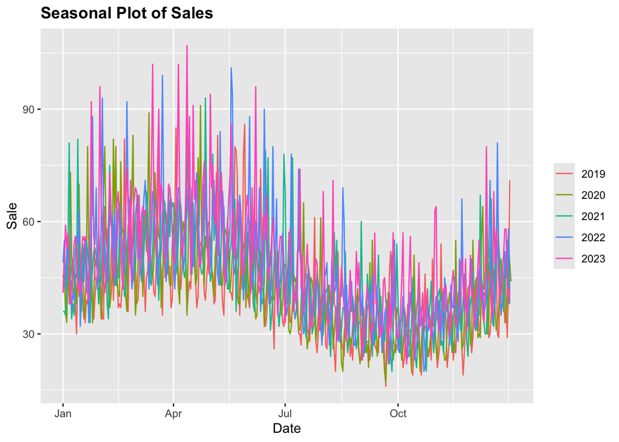

```r
gg_season(df_ts) +
  labs(title = 'Seasonal Plot of Sales',
           x = 'Date',
           y = 'Sale') + theme (
             plot.title = element_text(face = 'bold')
             )
```

```
## Plot variable not specified, automatically selected `y = sales`
```

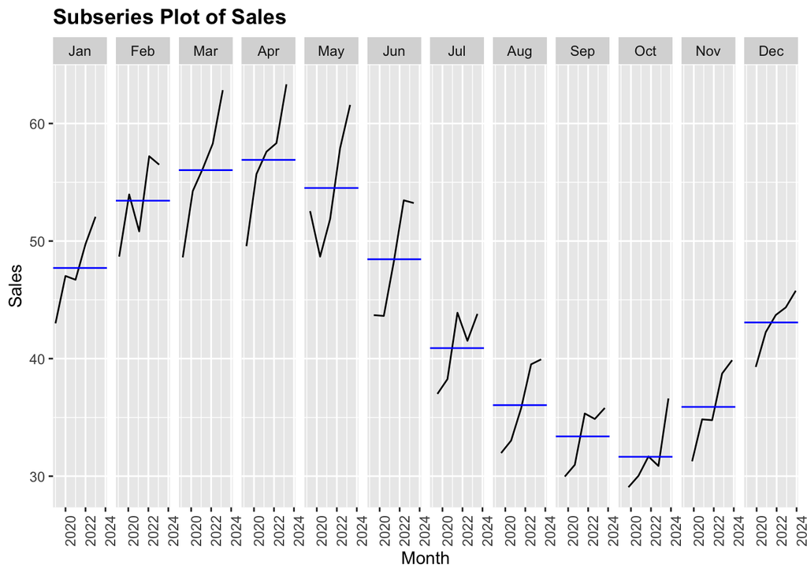

```r
# Create an aggregate monthly data to create a subseries plot
df_monthly <- df_ts %>%
  index_by(month = yearmonth(date)) %>%
  summarise(sales = mean(sales))

gg_subseries(df_monthly) +
  labs(title = 'Subseries Plot of Sales',
           x = 'Month',
           y = 'Sales') + theme (
             plot.title = element_text(face = 'bold')
           )
```

**Busiest Months** The subseries plot displays each month separately, with the blue horizontal line representing the average sales for that month across all years. By comparing the height of these blue lines across panels, we can identify which months are the busiest on average. Months with higher mean lines correspond to periods of stronger demand, while lower lines indicate slower months. Thus, busiest month across all years is April while slowest is October.

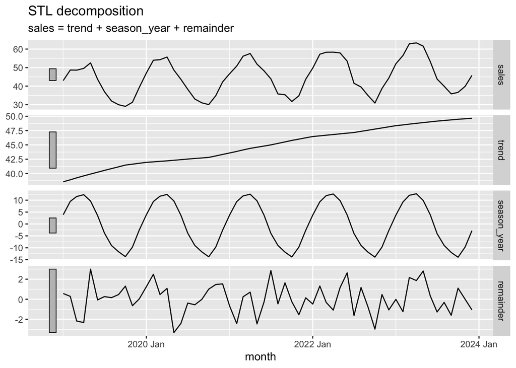

```r
df_monthly %>%
  model(STL(sales)) %>%
  components() %>%
  autoplot()
```

```r
# library(fpp3)
df_monthly <- df_monthly |> fill_gaps()             # Fill gaps as NA as the dataset ends at July 2023

fit <- df_monthly |> model(ETS(sales))
report(fit)
```

```
## Series: sales
## Model: ETS(M,A,M)
##   Smoothing parameters:
##     alpha = 0.0001098477
##     beta  = 0.0001002823
##     gamma = 0.000126117
##
##   Initial states:
##      l[0]      b[0]      s[0]     s[-1]     s[-2]     s[-3]     s[-4]     s[-5]
##  39.50536 0.1821122 0.9409701 0.7776118 0.6884856 0.7367621 0.7943168 0.9121311
##     s[-6]    s[-7]    s[-8]    s[-9]   s[-10]   s[-11]
##  1.085539 1.208019 1.286079 1.274523 1.213761 1.081802
##
##   sigma^2:  0.0015
##
##      AIC     AICc      BIC
## 324.0613 338.6327 359.6651
```

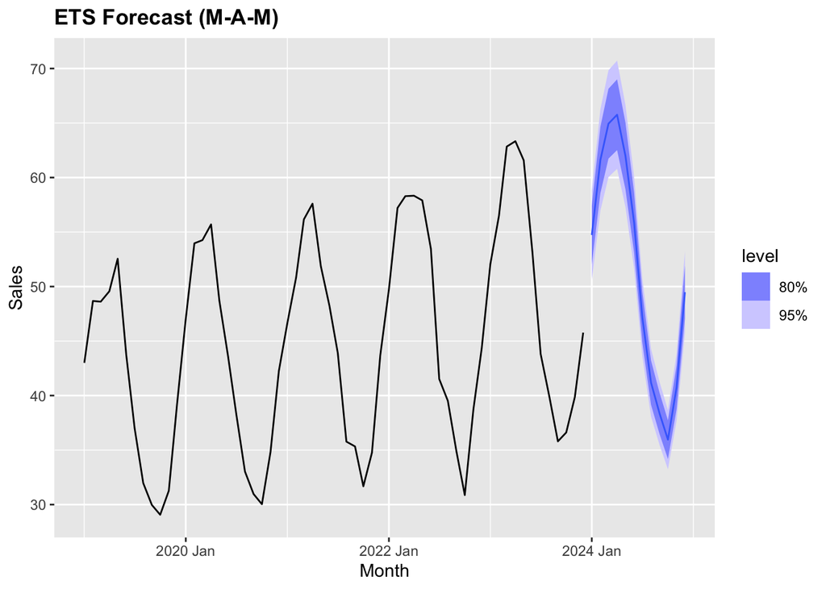

```r
fc <- fit |> forecast(h = "12 months")
autoplot(fc, df_monthly) +
  labs(title ='ETS Forecast (M-A-M)',
           x = 'Month',
           y = 'Sales') + theme (
             plot.title = element_text(face = 'bold')
           )
```

```r
# Checking the accuracy of the forecast
train <- df_monthly |> filter(month <= yearmonth("2021 Dec"))
test  <- df_monthly |> filter(month >= yearmonth("2022 Jan") & month <= yearmonth("2022 Dec"))

fit_train <- train |>
  model(ETS(sales ~ error("M") + trend("A") + season("M")))
fc <- fit_train |> forecast(h = nrow(test))

accuracy(fc, test)
```

```
## # A tibble: 1 × 10
##   .model                  .type    ME  RMSE   MAE   MPE  MAPE  MASE RMSSE   ACF1
##   <chr>                   <chr> <dbl> <dbl> <dbl> <dbl> <dbl> <dbl> <dbl>  <dbl>
## 1 "ETS(sales ~ error(\"M… Test  0.220  1.86  1.54 0.234  3.51   NaN   NaN -0.430
```

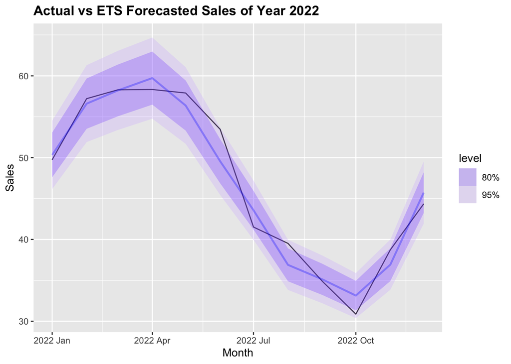

```r
autoplot(test, sales) +
  autolayer(fc, sales, alpha = 0.3, size = 0.9, colour = "blue") +
  labs(
    title = "Actual vs ETS Forecasted Sales of Year 2022",
    x = "Month",
    y = "Sales"
  ) + theme (
             plot.title = element_text(face = 'bold')
           )
```

```r
# Making an ARIMA forecast
fit_arima <- train |> model(ARIMA(sales))
report(fit_arima)
```

```
## Series: sales
## Model: ARIMA(0,0,0)(1,1,0)[12] w/ drift
##
## Coefficients:
##         sar1  constant
##       -0.573    3.4015
## s.e.   0.194    0.5323
##
## sigma^2 estimated as 4.718:  log likelihood=-54.01
## AIC=114.02   AICc=115.22   BIC=117.56
```

```r
fc_arima <- fit_arima |> forecast(h = nrow(test))
accuracy(fc_arima, test)
```

```
## # A tibble: 1 × 10
##   .model       .type     ME  RMSE   MAE    MPE  MAPE  MASE RMSSE    ACF1
##   <chr>        <chr>  <dbl> <dbl> <dbl>  <dbl> <dbl> <dbl> <dbl>   <dbl>
## 1 ARIMA(sales) Test  0.0942  2.43  2.00 -0.399  4.45   NaN   NaN -0.0740
```

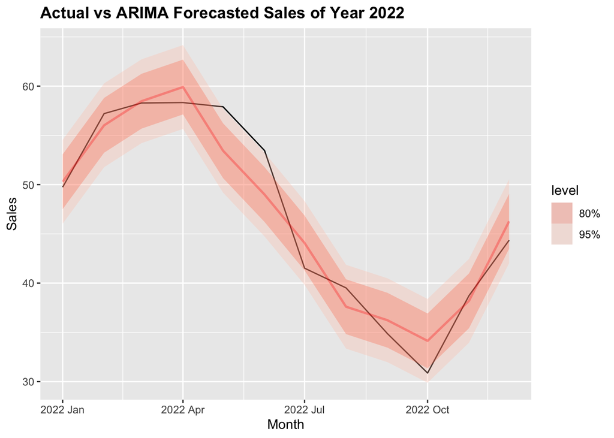

```r
autoplot(test, sales) +
  autolayer(fc_arima, sales, alpha = 0.3, colour = "red", size = 0.9) +
  labs(
    title = "Actual vs ARIMA Forecasted Sales of Year 2022",
    x = "Month",
    y = "Sales"
  ) + theme (
             plot.title = element_text(face = 'bold')
           )
```

```r
combined_accuracy <- bind_rows(
  accuracy(fc, test) |> mutate(model = "ETS"),
  accuracy(fc_arima, test) |> mutate(model = "ARIMA")
) |>
  select(model, ME, RMSE, MAE, MPE, MAPE, MASE, RMSSE, ACF1)

aic_table <- bind_rows(
  glance(fit_train) |> mutate(model = "ETS"),
  glance(fit_arima) |> mutate(model = "ARIMA")
) |>
  select(model, AIC, AICc, BIC)

aic_table
```

```
## # A tibble: 2 × 4
##   model   AIC  AICc   BIC
##   <chr> <dbl> <dbl> <dbl>
## 1 ETS    183.  217.  210.
## 2 ARIMA  114.  115.  118.
```

```r
combined_accuracy
```

```
## # A tibble: 2 × 9
##   model     ME  RMSE   MAE    MPE  MAPE  MASE RMSSE    ACF1
##   <chr>  <dbl> <dbl> <dbl>  <dbl> <dbl> <dbl> <dbl>   <dbl>
## 1 ETS   0.220   1.86  1.54  0.234  3.51   NaN   NaN -0.430
## 2 ARIMA 0.0942  2.43  2.00 -0.399  4.45   NaN   NaN -0.0740
```

**AIC and Forecast Accuracy** From the statistics aboce, ARIMA has the better model fit. However, combined accuracy table shows that the ETS model has lower forecast errors (MAE, MAPE, RMSE). In conclusion, while ARIMA fits better with historical data, ETS is more accurate with unseen data.

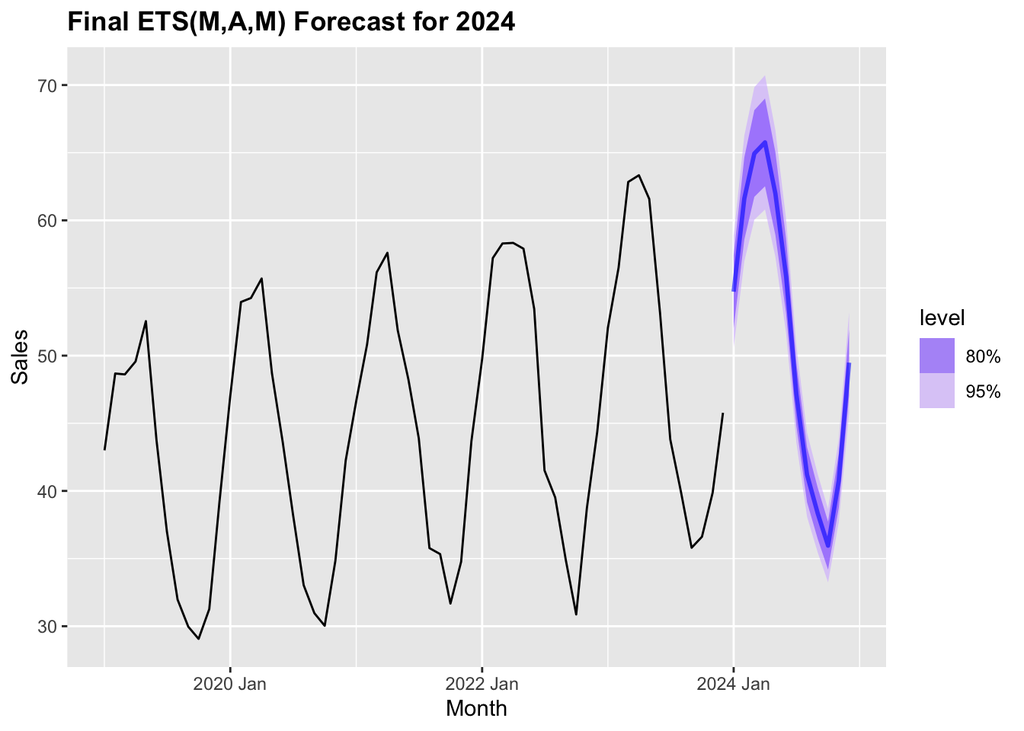

```r
final_fit <- df_monthly |>
  model(ETS(sales ~ error("M") + trend("A") + season("M")))
final_fc <- final_fit |> forecast(h = "12 months")

autoplot(df_monthly, sales, colour = "black") +
  autolayer(final_fc, .mean, alpha = 0.6, colour = "blue", size = 1.0) +
  labs(
    title = "Final ETS(M,A,M) Forecast for 2024",
    x = "Month",
    y = "Sales"
  ) + theme (
             plot.title = element_text(face = 'bold')
           )
```

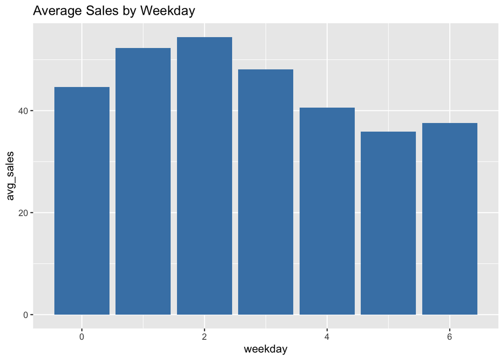

```r
# Further  analysis
# Visualizing the weekday data
daily_data <- df
daily_data |>
  group_by(weekday) |>                      # Group by weekday
  summarise(avg_sales = mean(sales)) |>     # Summarize the average sales
  arrange(desc(avg_sales)) |>               # Arrange average sales into descending order
  ggplot(aes(x = weekday, y = avg_sales)) +
  geom_col(fill = "steelblue") +
  labs(title = "Average Sales by Weekday")
```

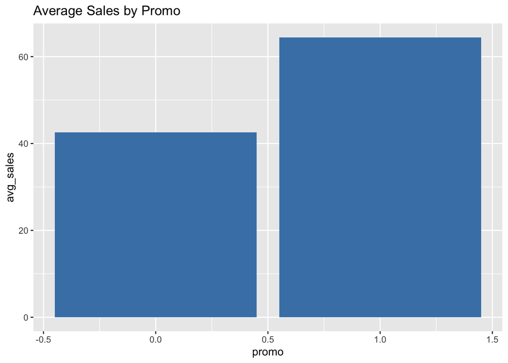

```r
# Checking Promo effectiveness
daily_data |>
  group_by(promo) |>
  summarise(avg_sales = mean(sales)) |>
  ggplot(aes(x = promo, y = avg_sales)) +
  geom_col(fill = "steelblue") +
  labs(title = "Average Sales by Promo")
```

```r
# Looking at the percent increase
no <- mean(daily_data$sales[daily_data$promo == 0])
yes <- mean(daily_data$sales[daily_data$promo == 1])
percent_change <- ((yes - no) / no) * 100
percent_change
```

```
## [1] 51.33151
```

```r
cor(daily_data$price, daily_data$sales)
```

```
## [1] -0.4782245
```

**Promo Days** Sales increased by 51.33% on promo days vs non-promo days. Further, there is a moderate negative relationship between price and sales, when price goes down, sales tend to go up and vice versa.

```r
model <- lm(sales ~ price + promo + factor(weekday), data = daily_data)
summary(model)
```

```
##
## Call:
## lm(formula = sales ~ price + promo + factor(weekday), data = daily_data)
##
## Residuals:
##     Min      1Q  Median      3Q     Max
## -26.782  -7.880  -0.573   8.218  34.218
##
## Coefficients: (1 not defined because of singularities)
##                  Estimate Std. Error t value Pr(>|t|)
## (Intercept)      147.6344     3.9787  37.106  < 2e-16 ***
## price             -4.9338     0.1881 -26.224  < 2e-16 ***
## promo                  NA         NA      NA       NA
## factor(weekday)1   6.8900     0.9017   7.641 3.46e-14 ***
## factor(weekday)2   9.2197     0.9015  10.227  < 2e-16 ***
## factor(weekday)3   4.0290     0.9015   4.469 8.34e-06 ***
## factor(weekday)4  -3.8256     0.9013  -4.244 2.30e-05 ***
## factor(weekday)5  -8.6649     0.9013  -9.614  < 2e-16 ***
## factor(weekday)6  -6.8180     0.9013  -7.564 6.15e-14 ***
## ---
## Signif. codes:  0 '***' 0.001 '**' 0.01 '*' 0.05 '.' 0.1 ' ' 1
##
## Residual standard error: 10.29 on 1818 degrees of freedom
## Multiple R-squared:  0.4435, Adjusted R-squared:  0.4413
## F-statistic: 206.9 on 7 and 1818 DF,  p-value: < 2.2e-16
```

**Statistical Analysis** The regression model shows that price has a strong and statistically negative effect towards sales. On average, increasing price by 1 unit reduces sales by 4.93 units. Weekday effects are also significant. Analysis shows that weekdays 1-3 shows igher sales relative to weekday 0, with weekday 2 being the busiest (+9.22). Weekdays 4–6 show lower sales, with weekday 5 being the slowest (–8.66 units). Overall, both price and weekday meaningfully explain variation in daily sales.